# Data Visualization: Part 2

### 0.2.4 Figures without legends

Even though legend legibility can be improved by encoding data redundantly, in multiple aesthetics, legends always put an extra mental burden on the reader. In reading a legend, the reader needs to pick up information in one part of the visualization and then transfer it over to a different part. We can typically make our readers’ lives easier if we eliminate the legend altogether. Eliminating the legend does not mean, however, that we simply not provide one and instead write sentences such as “The yellow dots represent *Iris versicolor*” in the figure caption. Eliminating the legend means that we design the figure in such a way that it is immediately obvious what the various graphical elements represent, even if no explicit legend is present.

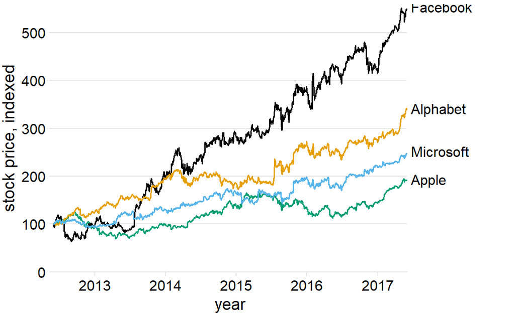

Figure 31: Stock price over time for four major tech companies. The stock price for each company has been normalized to equal 100 in June 2012. Data source: Yahoo Finance

```r
price_plot <- price_plot_base_good +
  geom_line(size = 0.66, na.rm = TRUE) +
  theme_dviz_hgrid()
yann <- axis_canvas(price_plot, axis = "y") +
  geom_text(
    data = filter(ungroup(tech_stocks), date == "2017-06-02"),
    aes(y = price_indexed, label = paste0(" ", company)),
    family = dviz_font_family,
    x = 0, hjust = 0, size = 12/.pt
  )
price_plot_ann <- insert_yaxis_grob(
  price_plot + theme(legend.position = "none"),
  yann,
  width = grid::unit(0.3, "null")
)
ggdraw(price_plot_ann)
```

Whenever possible, design your figures so they don’t need a legend.

We can also apply the direct labeling concept to the iris data from the beginning of this chapter, specifically Figure 26. Because it is a scatter plot of many points that separate into three different groups, we need to direct label the groups rather than the individual points. One solution is to draw ellipses that enclose the majority of the points and then label the ellipses (Figure 32).

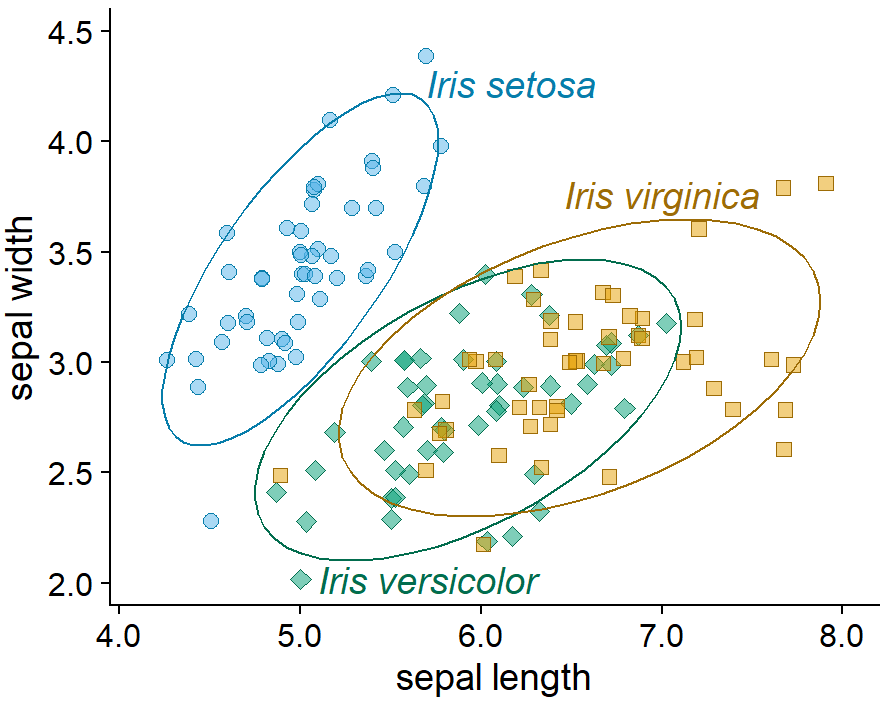

Figure 32: Sepal width versus sepal length for three different iris species. I have removed the background grid from this figure because otherwise the figure was becoming too busy.

```r
label_df <- data.frame(
  Species = c("setosa", "virginica", "versicolor"),
  label = c("Iris setosa", "Iris virginica", "Iris versicolor"),
  Sepal.Width = c(4.2, 3.76, 2.08),
  Sepal.Length = c(5.7, 7, 5.1),
  hjust = c(0, 0.5, 0),
  vjust = c(0, 0.5, 1))
iris_scatter3 <- ggplot(iris,
      aes(
        x = Sepal.Length,
        y = Sepal.Width,
        color = Species
      )
    ) +
    geom_point(
      aes(shape = Species, fill = Species),
      size = 2.5,
      position = position_jitter(
        width = 0.01 * diff(range(iris$Sepal.Length)),
        height = 0.01 * diff(range(iris$Sepal.Width)),
        seed = 3942)
    ) +
    stat_ellipse(size = 0.5) +
    geom_text(
      data = label_df,
      aes(
        x = Sepal.Length, y = Sepal.Width, label = label, color = Species,
        hjust = hjust, vjust = vjust
      ),
      family = dviz_font_family,
      size = 14/.pt,
      fontface = "italic",
      inherit.aes = FALSE
    ) +
    scale_shape_manual(
      values = c(21, 22, 23),
      breaks = breaks,
      name = NULL
    ) +
    scale_fill_manual(
      values = c("#56B4E980", "#E69F0080", "#009E7380"),
      breaks = breaks,
      name = NULL
    ) +
    scale_color_manual(
      values = darken(c("#56B4E9", "#E69F00", "#009E73"), 0.3),
      breaks = breaks,
      name = NULL
    ) +
    guides(fill = "none", color = "none", shape = "none") +
    scale_x_continuous(
      limits = c(3.95, 8.2), expand = c(0, 0),
      labels = c("4.0", "5.0", "6.0", "7.0", "8.0"),
      name = "sepal length"
    ) +
    scale_y_continuous(
      limits = c(1.9, 4.6), expand = c(0, 0),
      name = "sepal width"
    ) +
    theme_dviz_open()
iris_scatter3
```

For density plots, we can similarly direct-label the curves rather than providing a color-coded legend (Figure 33). In both Figures 32 and 33, I have colored the text labels in the same colors as the data. Colored labels can greatly enhance the direct labeling effect, but they can also turn out very poorly. If the text labels are printed in a color that is too light, then the labels become difficult to read. And, because text consists of very thin lines, colored text often appears to be lighter than an adjacent filled area of the same color. I generally circumvent these issues by using two different shades of each color, a light one for filled areas and a dark one for lines, outlines, and text. If you carefully inspect Figure 32 or 33, you will see how each data point or shaded area is filled with a light color and has an outline drawn in a darker color of the same hue. And the text labels are drawn in the same darker colors.

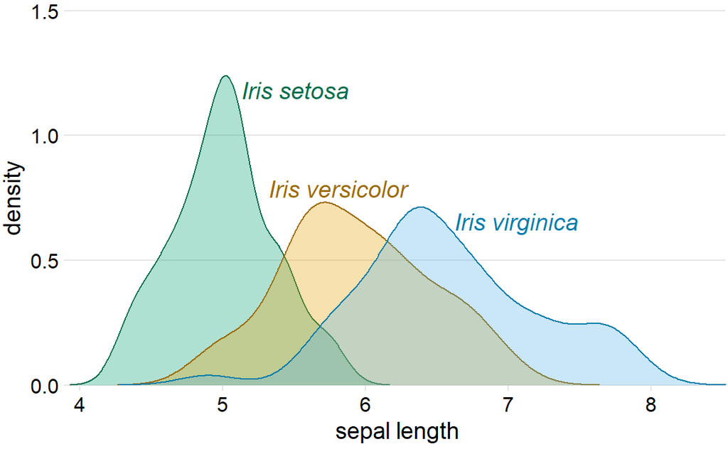

Figure 33: Density estimates of the sepal lengths of three different iris species. Each density estimate is directly labeled with the respective species name.

```r
# compute densities for sepal lengths
iris_dens <- group_by(iris, Species) %>%
  do(ggplot2:::compute_density(.$Sepal.Length, NULL)) %>%
  rename(Sepal.Length = x)
# get the maximum values
iris_max <- filter(iris_dens, density == max(density)) %>%
  ungroup() %>%
  mutate(
    hjust = c(0, 0.4, 0),
    vjust = c(1, 0, 1),
    nudge_x = c(0.11, 0, 0.24),
    nudge_y = c(-0.02, 0.02, -0.02),
    label = paste0("Iris ", Species)
  )
iris_p <- ggplot(iris_dens, aes(x = Sepal.Length, y = density, fill = Species, color = Species)) +
  geom_density_line(stat = "identity") +
  geom_text(
    data = iris_max,
    aes(
      label = label, hjust = hjust, vjust = vjust, color = Species,
      x = Sepal.Length + nudge_x,
      y = density + nudge_y
    ),
    family = dviz_font_family,
    size = 14/.pt,
    inherit.aes = FALSE,
    fontface = "italic"
  ) +
  scale_color_manual(
    values = darken(c("#56B4E9", "#E69F00", "#009E73"), 0.3),
    breaks = c("virginica", "versicolor", "setosa"),
    guide = "none"
  ) +
  scale_fill_manual(
    values = c("#56B4E950", "#E69F0050", "#009E7350"),
    breaks = c("virginica", "versicolor", "setosa"),
    guide = "none"
  ) +
  scale_x_continuous(expand = c(0, 0), name = "sepal length") +
  scale_y_continuous(limits = c(0, 1.5), expand = c(0, 0)) +
  coord_cartesian(clip = "off") +
  theme_dviz_hgrid() +
  theme(
    axis.line.x = element_blank(),
    plot.margin = margin(6.5, 1.5, 3.5, 1.5)
  )

iris_p
```

We can also use density plots such as the one in Figure 33 as a legend replacement, by placing the density plots into the margins of a scatter plot (Figure 34). This allows us to direct-label the marginal density plots rather than the central scatter plot and hence results in a figure that is somewhat less cluttered than Figure 32 with directly-labeled ellipses.

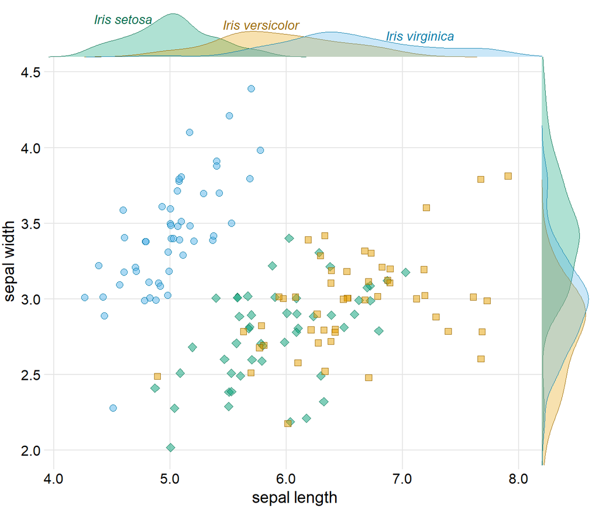

Figure 34: Sepal width versus sepal length for three different iris species, with marginal density estimates of each variable for each species.

```r
# compute densities for sepal lengths
iris_dens2 <- group_by(iris, Species) %>%
  do(ggplot2:::compute_density(.$Sepal.Width, NULL)) %>%
  rename(Sepal.Width = x)
dens_limit <- max(iris_dens$density, iris_dens2$density) * 1.05 # upper limit of density curves
# we need different hjust and nudge values here
iris_max <-
  iris_max %>%
  mutate(
    hjust = c(1, 0.4, 0),
    vjust = c(1, 0, 1),
    nudge_x = c(-0.18, 0, 0.47),
    nudge_y = c(-0.01, 0.06, 0.03),
    label = paste0("Iris ", Species)
  )
xdens <- axis_canvas(iris_scatter2, axis = "x") +
  geom_density_line(
    data=iris_dens,
    aes(x = Sepal.Length, y = density, fill = Species, color = Species),
    stat = "identity", size = .2
  ) +
  geom_text(
    data = iris_max,
    aes(
      label = label, hjust = hjust, vjust = vjust, color = Species,
      x = Sepal.Length + nudge_x,
      y = density + nudge_y
    ),
    family = dviz_font_family,
    ize = 12/.pt,
    #color = "black", inherit.aes = FALSE,
    fontface = "italic"
  ) +
  scale_color_manual(
    values = darken(c("#56B4E9", "#E69F00", "#009E73"), 0.3),
    breaks = c("virginica", "versicolor", "setosa"),
    guide = "none"
  ) +
  scale_fill_manual(
    values = c("#56B4E950", "#E69F0050", "#009E7350"),
    breaks = c("virginica", "versicolor", "setosa"),
    guide = "none"
  ) +
  scale_y_continuous(limits = c(0, dens_limit), expand = c(0, 0))
ydens <- axis_canvas(iris_scatter2, axis = "y", coord_flip = TRUE) +
  geom_density_line(
    data = iris_dens2,
    aes(x = Sepal.Width, y = density, fill = Species, color = Species),
    stat = "identity", size = .2
  )  +
  scale_color_manual(
    values = darken(c("#56B4E9", "#E69F00", "#009E73"), 0.3),
    breaks = c("virginica", "versicolor", "setosa"),
    guide = "none"
  ) +
  scale_fill_manual(
    values = c("#56B4E950", "#E69F0050", "#009E7350"),
    breaks = c("virginica", "versicolor", "setosa"),
    guide = "none"
  ) +
  scale_y_continuous(limits = c(0, dens_limit), expand = c(0, 0)) +
  coord_flip()
p1 <- insert_xaxis_grob(
  iris_scatter2 + theme(legend.position = "none"),
  xdens,
  grid::unit(3*14, "pt"), position = "top"
)
p2 <- insert_yaxis_grob(p1, ydens, grid::unit(3*14, "pt"), position = "right")
ggdraw(p2)
```

And finally, whenever we encode a single variable in multiple aesthetics, we don’t normally want multiple separate legends for the different aesthetics. Instead, there should be only a single legend-like visual element that conveys all mappings at once. In the case where we map the same variable onto a position along a major axis and onto color, this implies that the reference color bar should run along and be integrated into the same axis. Figure 35 shows a case where we map temperature to both a position along the *x* axis and onto color, and where we therefore have integrated the color legend into the *x* axis.

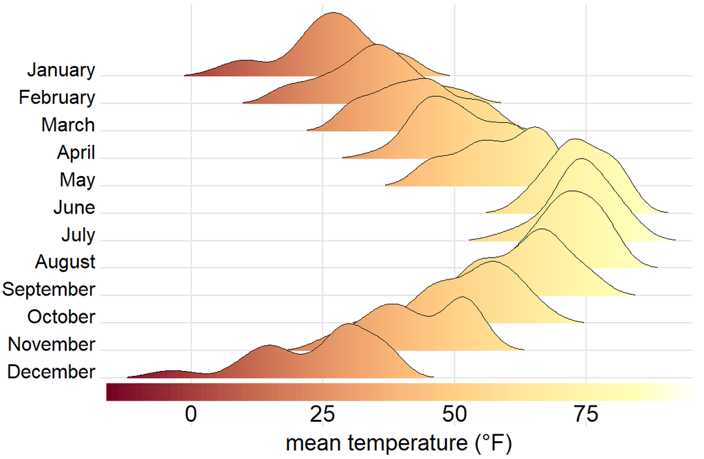

```r
bandwidth <- 3.4
lincoln_base <- ggplot(lincoln_weather, aes(x = `Mean Temperature [F]`, y = `Month`, fill = ..x..)) +
  geom_density_ridges_gradient(
    scale = 3, rel_min_height = 0.01, bandwidth = bandwidth,
    color = "black", size = 0.25
  ) +
  scale_x_continuous(
    name = "mean temperature (°F)",
    expand = c(0, 0), breaks = c(0, 25, 50, 75), labels = NULL
  ) +
  scale_y_discrete(name = NULL, expand = c(0, .2, 0, 2.6)) +
  scale_fill_continuous_sequential(
    palette = "Heat",
    l1 = 20, l2 = 100, c2 = 0,
    rev = FALSE
  ) +
  guides(fill = "none") +
  theme_dviz_grid() +
  theme(
    axis.text.y = element_text(vjust = 0),
    plot.margin = margin(3, 7, 3, 1.5)
  )
# x axis labels
temps <- data.frame(temp = c(0, 25, 50, 75))
# calculate corrected color ranges
# stat_joy uses the +/- 3*bandwidth calculation internally
tmin <- min(lincoln_weather$`Mean Temperature [F]`) - 3*bandwidth
tmax <- max(lincoln_weather$`Mean Temperature [F]`) + 3*bandwidth
xax <- axis_canvas(lincoln_base, axis = "x", ylim = c(0, 2)) +
  geom_ridgeline_gradient(
    data = data.frame(temp = seq(tmin, tmax, length.out = 100)),
    aes(x = temp, y = 1.1, height = .9, fill = temp),
    color = "transparent"
  ) +
  geom_text(
    data = temps, aes(x = temp, label = temp),
    color = "black", family = dviz_font_family,
    y = 0.9, hjust = 0.5, vjust = 1, size = 14/.pt
  ) +
  scale_fill_continuous_sequential(
    palette = "Heat",
    l1 = 20, l2 = 100, c2 = 0,
    rev = FALSE
  )
lincoln_final <- insert_xaxis_grob(lincoln_base, xax, position = "bottom", height = unit(0.1, "null"))
ggdraw(lincoln_final)
```

### 0.2.5 Multi-panel figures

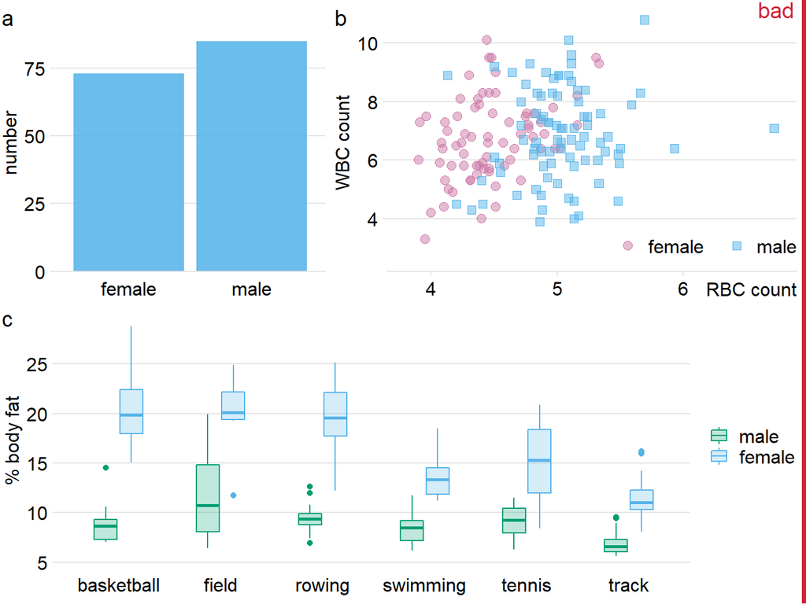

Figure 36: Physiology and body-composition of male and female athletes. (a) The data set encompasses 73 female and 85 male professional athletes. (b) Male athletes tend to have higher red blood cell (RBC, reported in units of $10^{12}$ per liter) counts than female athletes, but there are no such differences for white blood cell counts (WBC, reported in units of $10^{9}$ per liter). (c) Male athletes tend to have a lower body fat percentage than female athletes performing in the same sport. Data source: @Telford-Cunningham-1991

```r
male_sport <- unique(filter(Aus_athletes, sex=="m")$sport)
female_sport <- unique(filter(Aus_athletes, sex=="f")$sport)
both_sport <- male_sport[male_sport %in% female_sport]
athletes_df <- filter(Aus_athletes, sport %in% both_sport) %>%
  mutate(
    sport = case_when(
      sport == "track (400m)" ~ "track",
      sport == "track (sprint)" ~ "track",
      TRUE ~ sport
    ),
    sex = factor(sex, levels = c("f", "m"))
  )
p1 <- ggplot(athletes_df, aes(x = sex)) +
  geom_bar(fill = "#56B4E9E0") +
  scale_y_continuous(limits = c(0, 95), expand = c(0, 0), name = "number") +
  scale_x_discrete(name = NULL, labels = c("female", "male")) +
  theme_dviz_hgrid(12, rel_small = 1) +
  theme(
    axis.ticks.x = element_blank(),
    #axis.ticks.length = grid::unit(0, "pt"),
    plot.margin = margin(3, 0, 0, 0)
  )
p2 <- ggplot(athletes_df, aes(x = rcc, y = wcc, shape = sex, color = sex, fill = sex)) +
  geom_point(size = 2.5) +
  scale_x_continuous(limits = c(3.8, 6.75), name = NULL) +
  scale_y_continuous(limits = c(2.2, 11.), expand = c(0, 0), name = "WBC count") +
  scale_shape_manual(
    values = c(21, 22),
    labels = c("female   ", "male"), name = NULL,
    guide = guide_legend(direction = "horizontal")
  ) +
  scale_color_manual(
    values = c("#CC79A7", "#56B4E9"), name = NULL,
    labels = c("female   ", "male"),
    guide = guide_legend(direction = "horizontal")
  ) +
  scale_fill_manual(
    values = c("#CC79A780", "#56B4E980"), name = NULL,
    labels = c("female   ", "male"),
    guide = guide_legend(direction = "horizontal")
  ) +
  theme_dviz_hgrid(12, rel_small = 1) +
  theme(
    legend.position = c(1, .1),
    legend.justification = "right",
    legend.box.background = element_rect(fill = "white", color = "white"),
    plot.margin = margin(3, 0, 0, 0)
  )
p_row <- plot_grid(
  p1, NULL, p2,
  labels = c("a", "", "b"),
  align = 'h',
  nrow = 1,
  rel_widths = c(0.7, 0.02, 1)
) +
  draw_text(
    "RBC count", x = 1, y = 0.01, size = 12, hjust = 1, vjust = 0,
    family = dviz_font_family
  )
p3 <- ggplot(
  athletes_df,
  aes(
    x = sport, y = pcBfat, color = fct_relevel(sex, "m"),
    fill = fct_relevel(sex, "m")
  )
) +
  geom_boxplot(width = 0.5) +
  scale_color_manual(
    values = c("#009E73", "#56B4E9"), name = NULL,
    labels = c("male", "female")
  ) +
  scale_fill_manual(
    values = c("#009E7340", "#56B4E940"), name = NULL,
    labels = c("male", "female")
  ) +
  scale_x_discrete(name = NULL) +
  scale_y_continuous(name = "% body fat") +
  theme_dviz_hgrid(12, rel_small = 1) +
  theme(
    axis.line.x = element_blank(),
    axis.ticks.x = element_blank()
    #axis.ticks.length = grid::unit(0, "pt")
  )
stamp_bad(
  plot_grid(
    p_row, NULL, p3,
    ncol = 1,
    rel_heights = c(1, .04, 1),
    labels = c("", "", "c")
  ) +
  theme(plot.margin = margin(6, 6, 3, 1.5))
)
```

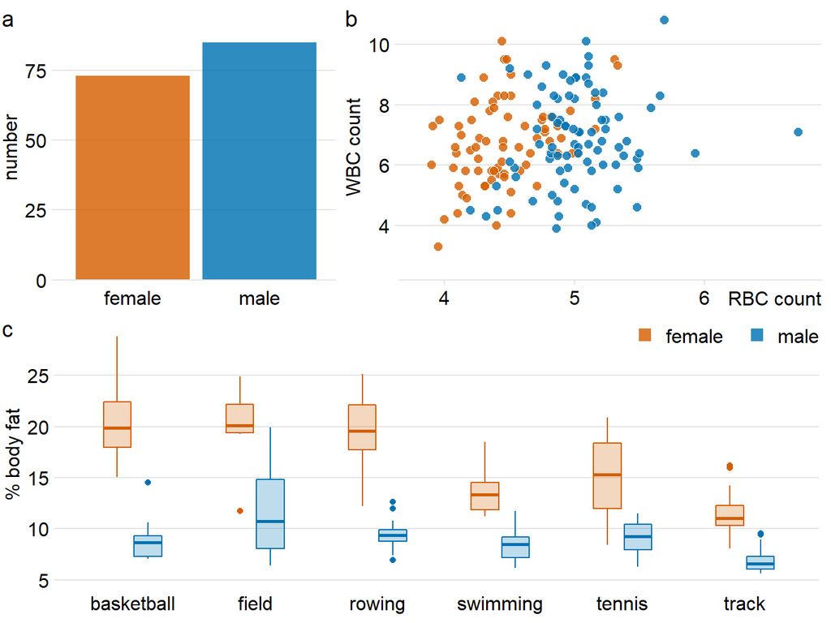

Figure 37: Physiology and body-composition of male and female athletes. This figure shows the exact same data as Figure 36, but now using a consistent visual language. Data for female athletes is always shown to the left of the corresponding data for male athletes, and genders are consistently color-coded throughout all elements of the figure. Data source: @Telford-Cunningham-1991

```r
p1 <- ggplot(athletes_df, aes(x = sex, fill = sex)) +
  geom_bar() +
  scale_y_continuous(limits = c(0, 95), expand = c(0, 0), name = "number") +
  scale_x_discrete(name = NULL, labels = c("female", "male")) +
  scale_fill_manual(values = c("#D55E00D0", "#0072B2D0"), guide = "none") +
  theme_dviz_hgrid(12, rel_small = 1) +
  theme(
    #axis.line.x = element_blank(),
    axis.ticks.x = element_blank(),
    #axis.ticks.length = grid::unit(0, "pt"),
    plot.margin = margin(3, 0, 0, 0)
  )
p2 <- ggplot(athletes_df, aes(x = rcc, y = wcc, fill = sex)) +
  geom_point(pch = 21, color = "white", size = 2.5) +
  scale_x_continuous(limits = c(3.8, 6.75), name = NULL) +
  scale_y_continuous(limits = c(2.2, 11.), expand = c(0, 0), name = "WBC count") +
  scale_fill_manual(values = c("#D55E00D0", "#0072B2D0"), guide = "none") +
  theme_dviz_hgrid(12, rel_small = 1) +
  theme(plot.margin = margin(3, 0, 0, 0))
p_row <- plot_grid(
  p1, NULL, p2,
  labels = c("a", "", "b"),
  align = 'h',
  nrow = 1,
  rel_widths = c(0.7, 0.02, 1)
) +
  draw_text(
    "RBC count", x = 1, y = 0.01, size = 12, hjust = 1, vjust = 0,
    family = dviz_font_family
  )
GeomBP <- GeomBoxplot
GeomBP$draw_key <- draw_key_polygon
p3 <- ggplot(athletes_df, aes(x = sport, y = pcBfat, color = sex, fill = sex)) +
  stat_boxplot(width = 0.5, geom = GeomBP) +
  scale_color_manual(
    values = c("#D55E00", "#0072B2"), name = NULL,
    labels = c("female   ", "male")) +
  scale_fill_manual(values = c("#D55E0040", "#0072B240"), guide = "none") +
  scale_x_discrete(name = NULL) +
  scale_y_continuous(name = "% body fat") +
  guides(color = guide_legend(
    override.aes = list(
      fill = c("#D55E00D0", "#0072B2D0"),
      color = "white", size = 2
    ),
    direction = "horizontal")
  ) +
  theme_dviz_hgrid(12, rel_small = 1) +
  theme(
    axis.line.x = element_blank(),
    axis.ticks.x = element_blank(),
    #axis.ticks.length = grid::unit(0, "pt"),
    legend.position = c(1., .96),
    legend.justification = "right"
  )
plot_grid(
  p_row, NULL, p3,
  ncol = 1,
  rel_heights = c(1, .04, 1),
  labels = c("", "", "c")
) +
  theme(plot.margin = margin(6, 6, 3, 1.5))
```

Finally, we need to pay attention to the alignment of individual figure panels in a compound figure. The axes and other graphical elements of the individual panels should all be aligned to each other. Getting the alignment right can be quite tricky, in particular if individual panels are prepared separately, possibly by different people and/or in different programs, and then pasted together in an image manipulation program. To draw your attention to such alignment issues, Figure 38 shows a variation of Figure 37 where now all figure elements are slightly out of alignment. I have added axis lines to all panels of Figure 38 to emphasize these alignment problems. Notice how no axis line is aligned with any other axis line for any other panel of the figure.

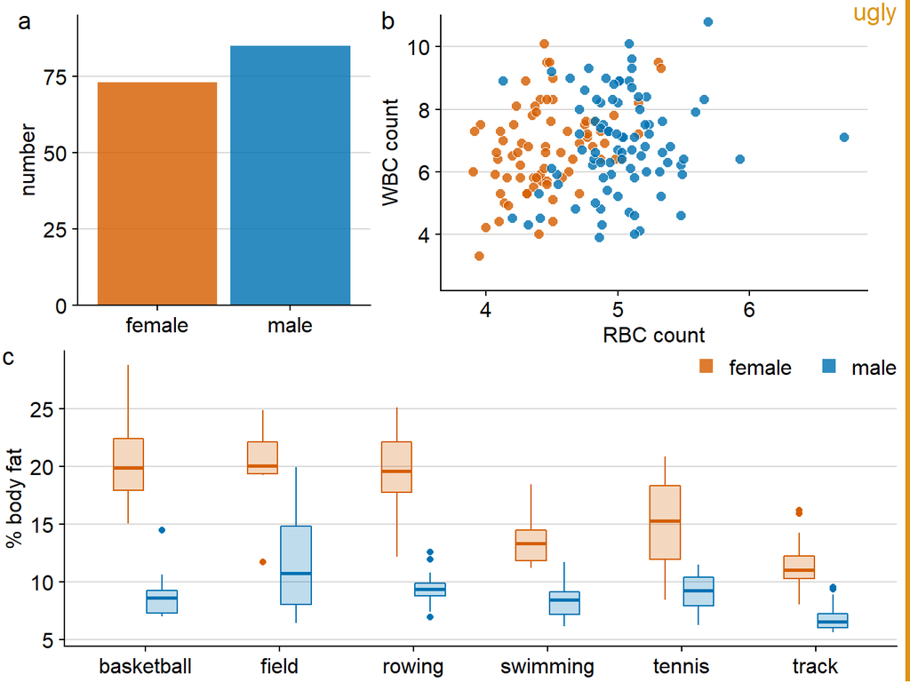

Figure 38: Variation of Figure 37 where all figure panels are slightly misaligned. Misalignments are ugly and should be avoided.

```r
p1 <- ggplot(athletes_df, aes(x = sex, fill = sex)) +
  geom_bar() +
  scale_y_continuous(limits = c(0, 95), expand = c(0, 0), name = "number") +
  scale_x_discrete(name = NULL, labels = c("female", "male")) +
  scale_fill_manual(values = c("#D55E00D0", "#0072B2D0"), guide = "none") +
  theme_dviz_open(12, rel_small = 1) +
  background_grid(major = "y") +
  theme(
    #axis.line.x = element_blank(),
    #axis.ticks.x = element_blank(),
    #axis.ticks.length = grid::unit(0, "pt"),
    plot.margin = margin(3, 6, 6, 0)
  )
p2 <- ggplot(athletes_df, aes(x = rcc, y = wcc, fill = sex)) +
  geom_point(pch = 21, color = "white", size = 2.5) +
  scale_x_continuous(limits = c(3.8, 6.75), name = "RBC count") +
  scale_y_continuous(limits = c(2.2, 11.), expand = c(0, 0), name = "WBC count") +
  scale_fill_manual(values = c("#D55E00D0", "#0072B2D0"), guide = "none") +
  theme_dviz_open(12, rel_small = 1) +
  background_grid(major = "y") +
  theme(plot.margin = margin(3, 18, 0, 0))
p_row <- plot_grid(
  NULL, p1, p2, labels = c("", "a", "b"), nrow = 1,
  rel_widths = c(0.03, 0.7, 1)
)
GeomBP <- GeomBoxplot
GeomBP$draw_key <- draw_key_polygon
p3 <- ggplot(athletes_df, aes(x = sport, y = pcBfat, color = sex, fill = sex)) +
  stat_boxplot(width = 0.5, geom = GeomBP) +
  scale_color_manual(
    values = c("#D55E00", "#0072B2"), name = NULL,
    labels = c("female   ", "male")
  ) +
  scale_fill_manual(values = c("#D55E0040", "#0072B240"), guide = "none") +
  scale_x_discrete(name = NULL) +
  scale_y_continuous(name = "% body fat") +
  guides(color = guide_legend(
    override.aes = list(
      fill = c("#D55E00D0", "#0072B2D0"),
      color = "white", size = 2
    ),
    direction = "horizontal")
  ) +
  theme_dviz_open(12, rel_small = 1) +
  background_grid(major = "y") +
  theme(
    #axis.line.x = element_blank(),
    #axis.ticks.x = element_blank(),
    #axis.ticks.length = grid::unit(0, "pt"),
    legend.position = c(1., 0.95),
    legend.justification = "right"
  )
stamp_ugly(
  plot_grid(
    p_row, p3, ncol = 1, labels = c("", "c")
  ) +
  theme(plot.margin = margin(6, 6, 0, 1.5))
)
```

### 0.2.6 Titles and Captions

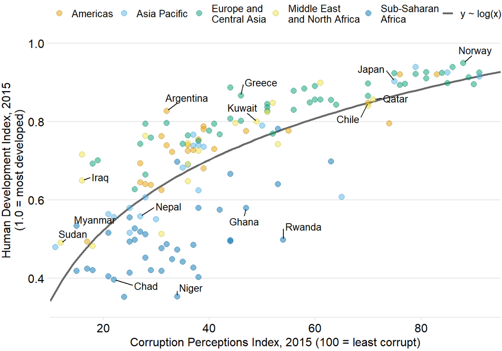

Figure 39: Corruption and human development: The most developed countries experience the least corruption. This figure was inspired by a posting in @Economist-corruption. Data sources: Transparency International & UN Human Development Report

```r
country_highlight <- c("Germany", "Norway", "United States", "Greece", "Singapore", "Rwanda", "Russia", "Venezuela", "Sudan", "Iraq", "Ghana", "Niger", "Chad", "Kuwait", "Qatar", "Myanmar", "Nepal", "Chile", "Argentina", "Japan", "China")
corruption %>% filter(year == 2015) %>% na.omit() %>%
  mutate(region = case_when(
    region == "Middle East and North Africa" ~ "Middle East\nand North Africa",
    region == "Europe and Central Asia" ~ "Europe and\nCentral Asia",
    region == "Sub Saharan Africa" ~ "Sub-Saharan\nAfrica",
    TRUE ~ region),
    label = ifelse(country %in% country_highlight, country, "")
    ) %>%
  ggplot(aes(cpi, hdi)) +
    geom_smooth(
      aes(color = "y ~ log(x)", fill = "y ~ log(x)"),
      method = 'lm', formula = y~log(x), se = FALSE, fullrange = TRUE
    ) +
    geom_point(
      aes(color = region, fill = region),
      size = 2.5, alpha = 0.5, shape = 21
    ) +
    geom_text_repel(
      aes(label = label), color = "black", size = 10/.pt,
      point.padding = 0.1, box.padding = .6, force = 1.,
      min.segment.length = 0, seed = 7654,
      family = dviz_font_family
    ) +
    scale_color_OkabeIto(name = NULL, order = c(1:5, 8), darken = 0.3) +
    scale_fill_OkabeIto(name = NULL, order = c(1:5, 8)) +
    scale_y_continuous(
      limits = c(0.3, 1.05), breaks = c(0.2, 0.4, 0.6, 0.8, 1.0),
      expand = c(0, 0),
      name = "Human Development Index, 2015\n(1.0 = most developed)"
    ) +
    scale_x_continuous(
      limits = c(10, 95),
      breaks = c(20, 40, 60, 80, 100),
      expand = c(0, 0),
      name = "Corruption Perceptions Index, 2015 (100 = least corrupt)"
    ) +
    guides(
      color = guide_legend(
        nrow = 1,
        override.aes = list(
          linetype = c(rep("blank", 5), "solid"),
          shape = c(rep(21, 5), NA)
        )
      )
    ) +
    theme_dviz_hgrid(12, rel_small = 1) +
    theme(
      legend.position = "top",
      legend.justification = "right",
      legend.text = element_text(size = 10),
      legend.box.spacing = unit(0, "pt")
    ) -> plot_corrupt_base
## for some reason grid::forceGrob creates an empty plot, not sure why
#cur_dev <- grDevices::dev.cur()
#cowplot::png_null_device(width = 7, height = 4.9)
#null_dev <- dev.cur()
#grob_corrupt_base <- grid::forceGrob(ggplotGrob(plot_corrupt_base))
#null <- grDevices::dev.off(null_dev)
#if (cur_dev > 1 ) null <- grDevices::dev.set(cur_dev)
ggdraw(plot_corrupt_base)
```

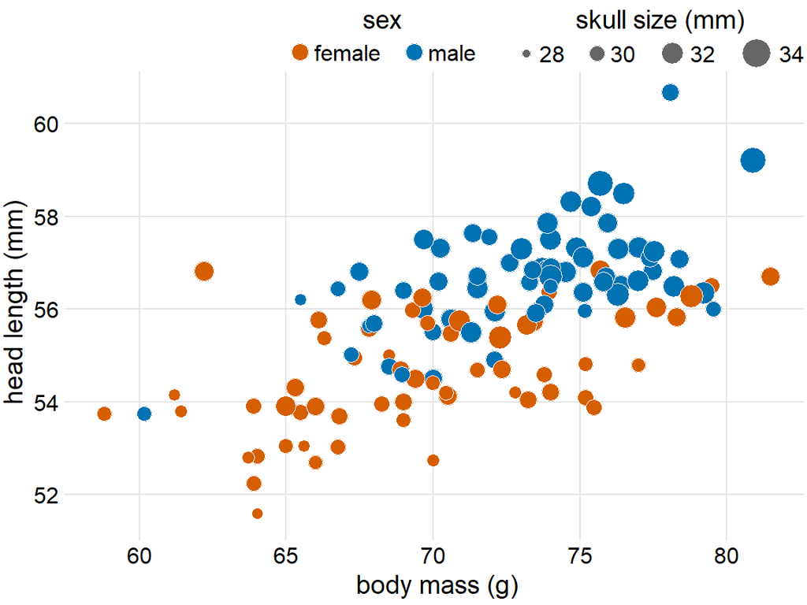

Figure 40: Head length versus body mass for 123 blue jays. The birds’ sex is indicated by color, and the birds’ skull size by symbol size. Head-length measurements include the length of the bill while skull-size measurements do not. Data source: Keith Tarvin, Oberlin College

```r
blue_jays$sex <- ifelse(blue_jays$KnownSex == "F", "female birds", "male birds")
blue_jays$sex <- factor(blue_jays$sex, levels = c("male birds", "female birds"))
ggplot(blue_jays, aes(Mass, Head, size = Skull, fill = KnownSex)) +
  geom_point(pch = 21, color = "white") +
  scale_x_continuous(name = "body mass (g)") +
  scale_y_continuous(name = "head length (mm)", breaks = c(52, 54, 56, 58, 60)) +
  scale_fill_manual(
    values = c(F = "#D55E00", M = "#0072B2"),
    labels = c("female   ", "male"),
    name = "sex",
    guide = guide_legend(
      direction = "horizontal",
      title.position = "top",
      title.hjust = 0.5,
      label.position = "right",
      keyheight = grid::unit(19, "pt"),
      order = 1,
      override.aes = list(size = 4)
    )
  ) +
  scale_radius(
    name = "skull size (mm)",
    range = c(2, 7),
    limits = c(28, 34),
    breaks = c(28, 30, 32, 34),
    labels = c("28   ", "30   ", "32   ", "34"),
    guide = guide_legend(
      direction = "horizontal",
      title.position = "top",
      title.hjust = 0.5,
      label.position = "right",
      order = 2,
      override.aes = list(fill = "gray40")
    )
  ) +
  theme_dviz_grid() +
  theme(
    legend.margin = margin(0, 0, 0, 20),
    legend.position = "top",
    legend.box = "horizontal",
    legend.box.spacing = grid::unit(0, "pt"),
    legend.justification = c(1, 0),
    legend.spacing.x = unit(2, "pt"),
    legend.spacing.y = unit(2, "pt"),
    legend.background = element_rect(fill = "white", color = NA),
    legend.key.width = unit(10, "pt")
  )
```

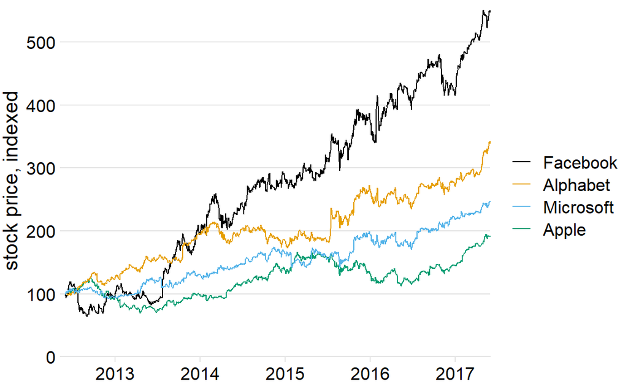

Figure 41: Stock price over time for four major tech companies. The stock price for each company has been normalized to equal 100 in June 2012. This figure is a slightly modified version of Figure 29 in Chapter 0.2.3. Here, the *x* axis representing time does not have a title. It is clear from the context that the numbers 2013, 2014, etc. refer to years.

```r
price_plot_base <- ggplot(ungroup(tech_stocks), aes(x = date, y = price_indexed, color = ticker)) +
  geom_line(na.rm = TRUE) +
  scale_color_manual(
    values = c("#000000", "#E69F00", "#56B4E9", "#009E73"),
    name = "",
    breaks = c("FB", "GOOG", "MSFT", "AAPL"),
    labels = c("Facebook", "Alphabet", "Microsoft", "Apple")
  ) +
  scale_x_date(
    limits = c(ymd("2012-06-01"), ymd("2017-05-31")),
    expand = c(0,0)
  ) +
  scale_y_continuous(
    limits = c(0, 560),
    expand = c(0,0)
  ) +
  theme_dviz_hgrid() +
  theme(plot.margin = margin(3, 7, 3, 1.5))
price_plot_base + xlab(NULL) + ylab("stock price, indexed")
```

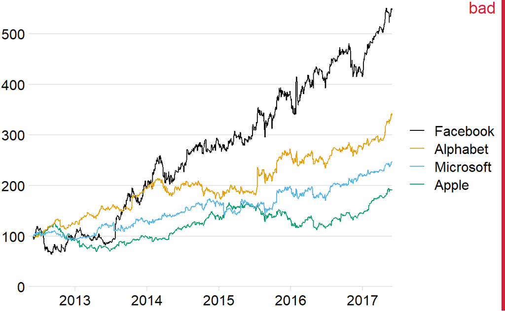

Figure 42: Stock price over time for four major tech companies. The stock price for each company has been normalized to equal 100 in June 2012. This variant of Figure 41 has been labeled as “bad” because the *y* axis now does not have a title either, and what the values shown along the *y* axis represent is not immediately obvious from the context.

```r
stamp_bad(
  price_plot_base + xlab(NULL) + ylab(NULL)
)
```

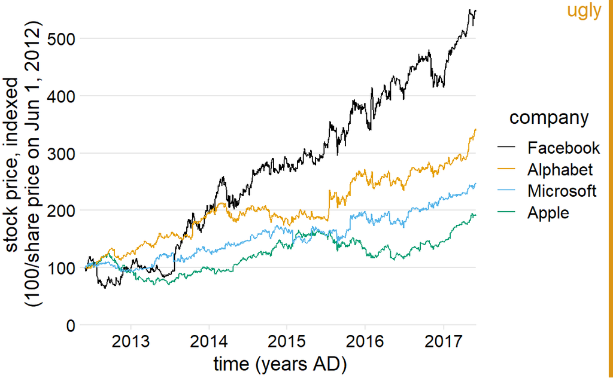

Figure 43: Stock price over time for four major tech companies. The stock price for each company has been normalized to equal 100 in June 2012. This variant of Figure 41 has been labeled as “ugly” because it is labeled excessively. In particular, providing a unit (“years AD”) for the values along the *x* axis is awkward.

```r
stamp_ugly(
  price_plot_base + xlab("time (years AD)") + ylab("stock price, indexed\n(100/share price on Jun 1, 2012)") +
    scale_color_manual(
      values = c("#000000", "#E69F00", "#56B4E9", "#009E73"),
      name = "company",
      breaks = c("FB", "GOOG", "MSFT", "AAPL"),
      labels = c("Facebook", "Alphabet", "Microsoft", "Apple")
    ) +
    theme(legend.title.align = 0.5)
)
```

### 0.2.7 Balancee data with context

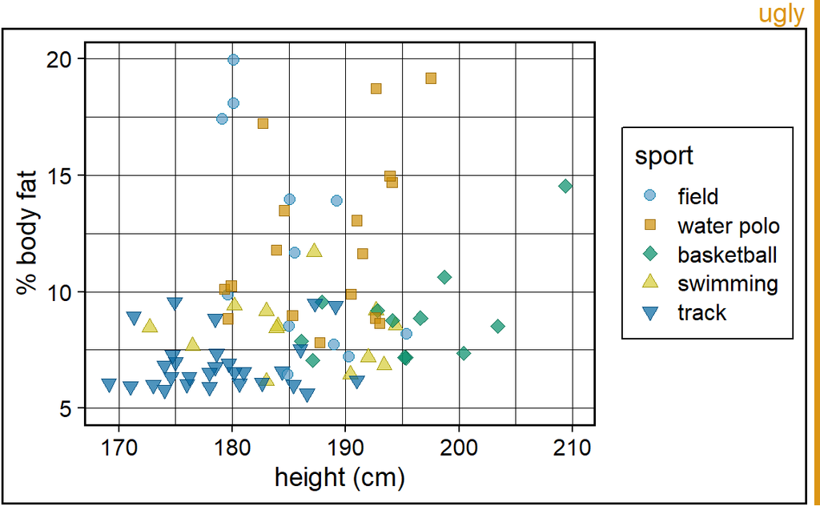

Figure 44: Percent body fat versus height in professional male Australian athletes. Each point represents one athlete. This figure devotes way too much ink to non-data. There are unnecessary frames around the entire figure, around the plot panel, and around the legend. The coordinate grid is very prominent, and its presence draws attention away from the data points. Data source: @Telford-Cunningham-1991

```r
male_Aus <- filter(Aus_athletes, sex=="m") %>%
    filter(sport %in% c("basketball", "field", "swimming", "track (400m)",
                        "track (sprint)", "water polo")) %>%
    mutate(sport = case_when(sport == "track (400m)" ~ "track",
                             sport == "track (sprint)" ~ "track",
                             TRUE ~ sport))
male_Aus$sport <- factor(male_Aus$sport,
                         levels = c("field", "water polo", "basketball", "swimming", "track"))
p_Aus_base <- ggplot(male_Aus, aes(x=height, y=pcBfat, color=sport, fill=sport, shape=sport)) +
  geom_point(size = 2.5) +
  scale_shape_manual(values = 21:25) +
  scale_color_OkabeIto(order=c(2, 1, 3, 4, 5), darken = 0.3) +
  scale_fill_OkabeIto(order=c(2, 1, 3, 4, 5), darken = 0.1, alpha = 0.7) +
  scale_x_continuous(limits = c(169, 210), name = "height (cm)") +
  scale_y_continuous(limits = c(5, 20), name = "% body fat")
p <- p_Aus_base +
  theme_dviz_open() +
  theme(
    axis.line = element_blank(),
    panel.grid.major = element_line(color = "black", size = 0.3),
    panel.grid.minor = element_line(color = "black", size = 0.15),
    panel.border = element_rect(color = "black", size = 1),
    legend.background = element_rect(color = "black", size = 0.5),
    legend.margin = margin(7, 7, 7, 7),
    plot.background = element_rect(color = "black", size = 1),
    plot.margin = margin(7, 7, 7, 7)
  )
# width: 6 in = 433.62pt
# height: 0.618 * 6 in = 3.71 in = 268.12
stamp_ugly(ggdraw() + draw_plot(p, x = 1/434, y = 1/268, width = 426/434, height = 252/268))
```

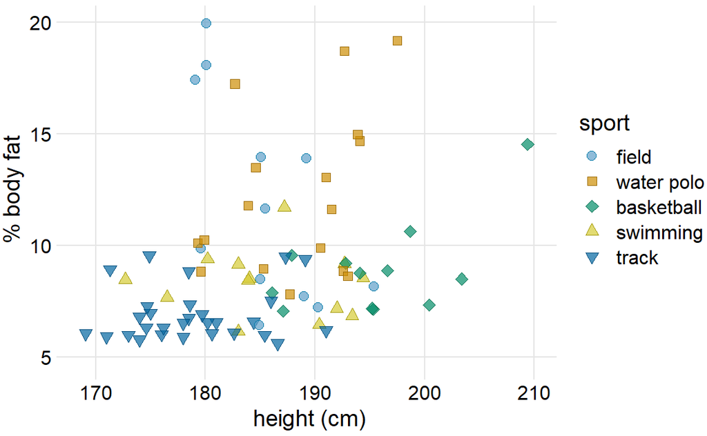

Figure 45: Percent body fat versus height in professional male Australian athletes. This figure is a cleaned-up version of Figure 44. Unnecessary frames have been removed, minor grid lines have been removed, and major grid lines have been drawn in light gray to stand back relative to the data points. Data source: @Telford-Cunningham-1991

```r
p_Aus_base +
  theme_dviz_grid()# + panel_border(colour = "grey70") + theme(axis.ticks = element_line(colour = "grey70"))
```

At the other extreme, we might end up with a figure such as Figure 46, which is a minimalist version of Figure 45. In this figure, the axis tick labels and titles have been made so faint that they are hard to see. If we just glance at the figure we will not immediately perceive what data is actually shown. We only see points floating in space. Moreover, the legend annotations are so faint that the points in the legend could be mistaken for data points. This effect is amplified because there is no clear visual separation between the plot area and the legend. Notice how the background grid in Figure 45 both anchors the points in space and sets off the data area from the legend area. Both of these effects have been lost in Figure 46.

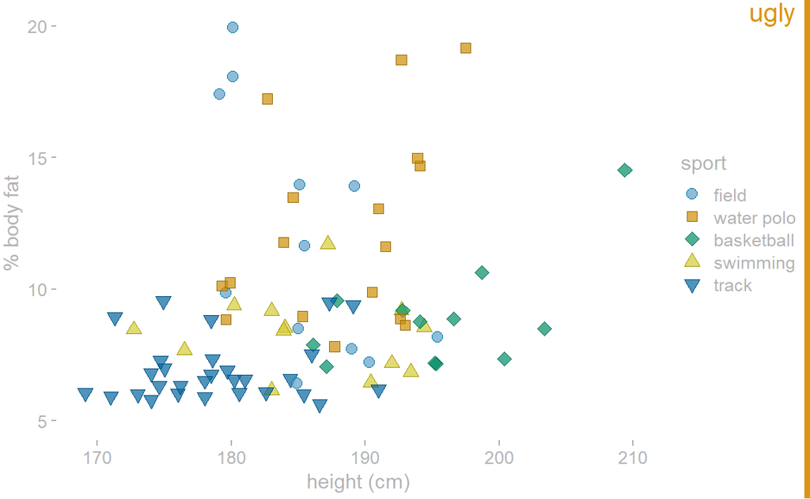

Figure 46: Percent body fat versus height in professional male Australian athletes. In this example, the concept of removing non-data ink has been taken too far. The axis tick labels and title are too faint and are barely visible. The data points seem to float in space. The points in the legend are not sufficiently set off from the data points, and the casual observer might think they are part of the data. Data source: @Telford-Cunningham-1991

```r
axis_col <- "grey70"
title_col <- "grey70"
p <- p_Aus_base + theme_dviz_open(11) +
  theme(
    axis.line = element_blank(),
    axis.ticks = element_line(color = axis_col),
    axis.text = element_text(color = axis_col),
    axis.title = element_text(color = title_col),
    legend.text = element_text(color = title_col),
    legend.title = element_text(color = title_col),
    plot.margin = margin(3.5, 7, 3.5, 1.5)
  )
stamp_ugly(p)
```

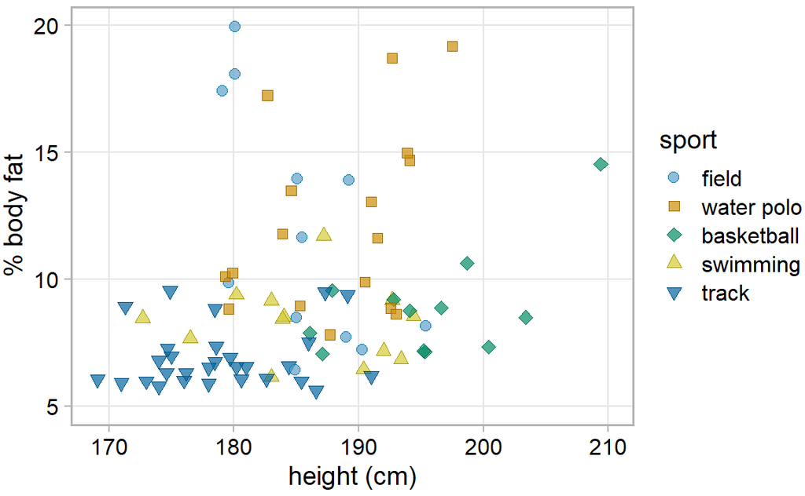

Figure 47: Percent body fat versus height in professional male Australian athletes. This figure adds a frame around the plot panel of Figure 45, and this frame helps separate the legend from the data. Data source: @Telford-Cunningham-1991

```r
p_Aus_base +
  theme_dviz_grid() + panel_border(colour = "grey70") + theme(axis.ticks = element_line(colour = "grey70"))
```

### 0.2.8 Backgrounds

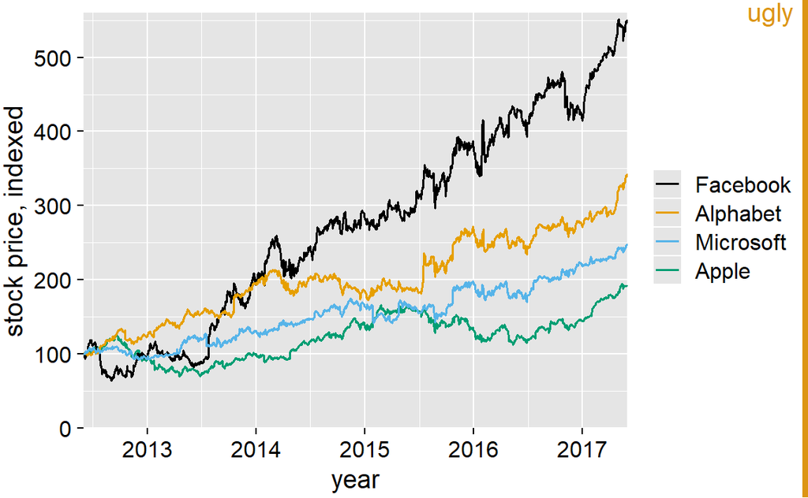

Figure 48: Stock price over time for four major tech companies. The stock price for each company has been normalized to equal 100 in June 2012. This figure mimics the ggplot2 default look, with white major and minor grid lines on a gray background. In this particular example, I think the grid lines overpower the data lines, and the result is a figure that is not well balanced and that doesn’t place sufficient emphasis on the data. Data source: Yahoo Finance

```r
price_plot <- ggplot(ungroup(tech_stocks), aes(x=date, y=price_indexed, color=ticker)) +
  geom_line(size = 0.66, na.rm = TRUE) +
  scale_color_manual(
    values = c("#000000", "#E69F00", "#56B4E9", "#009E73"),
    name = NULL,
    breaks = c("FB", "GOOG", "MSFT", "AAPL"),
    labels = c("Facebook", "Alphabet", "Microsoft", "Apple")
  ) +
  scale_x_date(
    name="year",
    limits=c(ymd("2012-06-01"), ymd("2017-05-31")),
    expand=c(0,0)
  ) +
  scale_y_continuous(
    name = "stock price, indexed",
    limits = c(0, 560),
    expand = c(0,0)
  ) +
  theme_dviz_grid() +
  theme(
    panel.background = element_rect(fill = "grey90"),
    panel.grid.major = element_line(color = "white"),
    panel.grid.minor = element_line(color = "white", size = rel(0.5)),
    legend.key = element_rect(fill = "grey90", color = "white"),
    axis.ticks = element_line(color = "black"),
    plot.margin = margin(7, 7, 3, 1.5)
  )
stamp_ugly(price_plot)
```

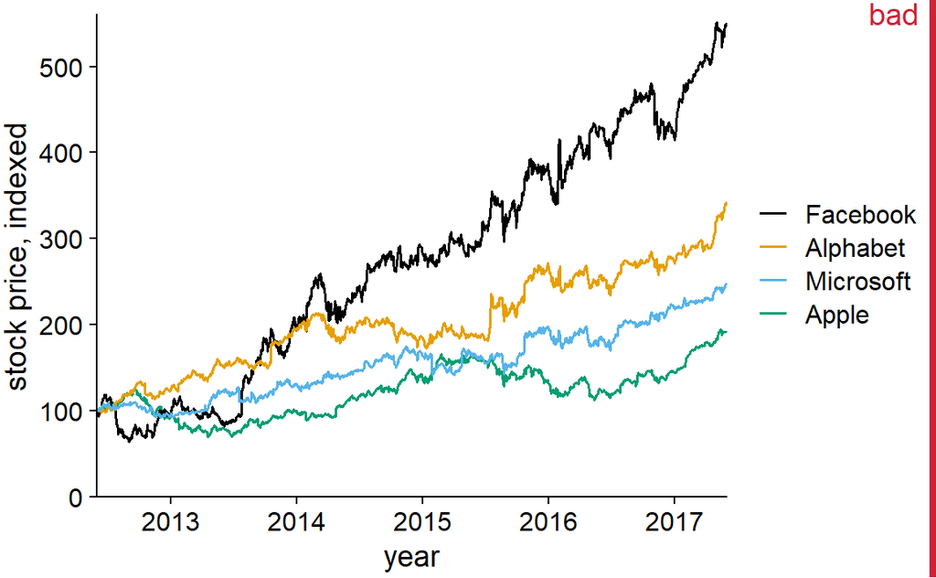

Figure 49: Indexed stock price over time for four major tech companies. In this variant of Figure 48, the data lines are not sufficiently anchored. This makes it difficult to ascertain to what extent they have deviated from the index value of 100 at the end of the covered time interval. Data source: Yahoo Finance

```r
stamp_bad(
  price_plot +
    theme_dviz_open() +
    theme(plot.margin = margin(7, 7, 3, 1.5))
)
```

At the absolute minimum, we need to add one horizontal reference line. Since the stock prices in Figure 49 indexed to 100 in June 2012, marking this value with a thin horizontal line at *y* = 100 helps a lot (Figure 50). Alternatively, we can use a minimal “grid” of horizontal lines. For a plot where we are primarily interested in the change in *y* values, vertical grid lines are not needed. Moreover, grid lines positioned at only the major axis ticks will often be sufficient. And, the axis line can be omitted or made very thin, since the horizontal lines clearly mark the extent of the plot (Figure 51).

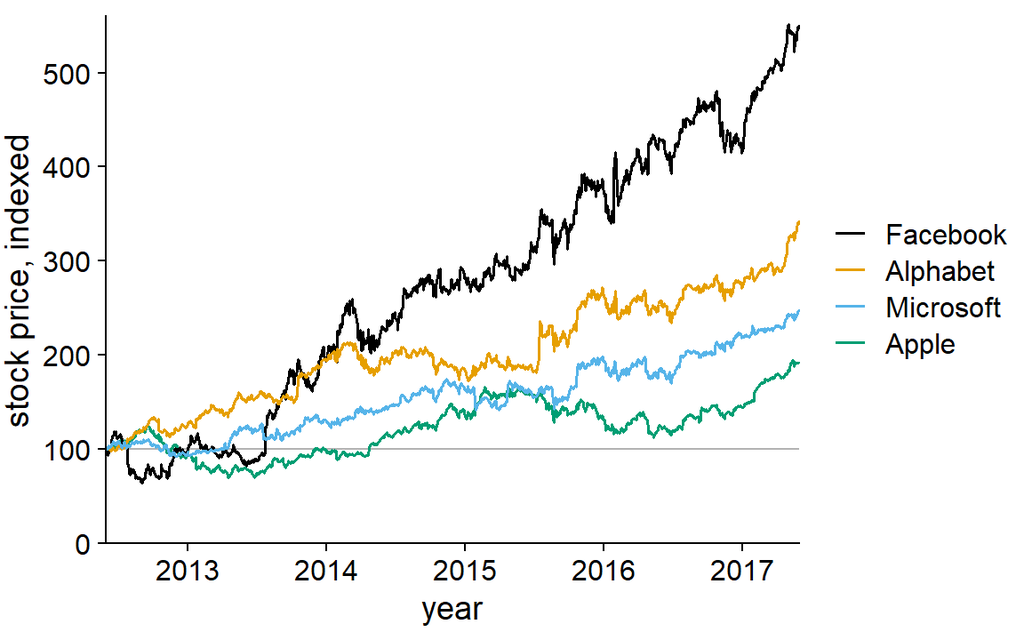

Figure 50: Indexed stock price over time for four major tech companies. Adding a thin horizontal line at the index value of 100 to Figure 49 helps provide an important reference throughout the entire time period the plot spans. Data source: Yahoo Finance

```r
price_plot2 <- ggplot(ungroup(tech_stocks), aes(x=date, y=price_indexed, color=ticker)) +
  geom_hline(yintercept = 100, size = 0.5, color="grey70") +
  geom_line(size = 0.66, na.rm = TRUE) +
  scale_color_manual(
    values = c("#000000", "#E69F00", "#56B4E9", "#009E73"),
    name = NULL,
    breaks = c("FB", "GOOG", "MSFT", "AAPL"),
    labels = c("Facebook", "Alphabet", "Microsoft", "Apple")
  ) +
  scale_x_date(
    name = "year",
    limits = c(ymd("2012-06-01"), ymd("2017-05-31")),
    expand = c(0,0)
  ) +
  scale_y_continuous(
    name = "stock price, indexed",
    limits = c(0, 560),
    expand = c(0,0)
  ) +
  theme_dviz_open() +
  theme(plot.margin = margin(7, 7, 3, 1.5))
price_plot2
```

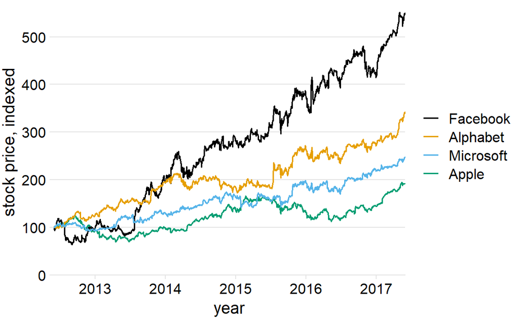

Figure 51: Indexed stock price over time for four major tech companies. Adding thin horizontal lines at all major *y* axis ticks provides a better set of reference points than just the one horizontal line of Figure 50. This design also removes the need for prominent *x* and *y* axis lines, since the evenly spaced horizontal lines create a visual frame for the plot panel. Data source: Yahoo Finance

```r
price_plot +
  theme_dviz_hgrid() +
  theme(plot.margin = margin(7, 7, 3, 1.5))
```

For such a minimal grid, we generally draw the lines orthogonally to direction along which the numbers of interest vary. Therefore, if instead of plotting the stock price over time we plot the five-year increase, as horizontal bars, then we will want to use vertical lines instead (Figure 52).

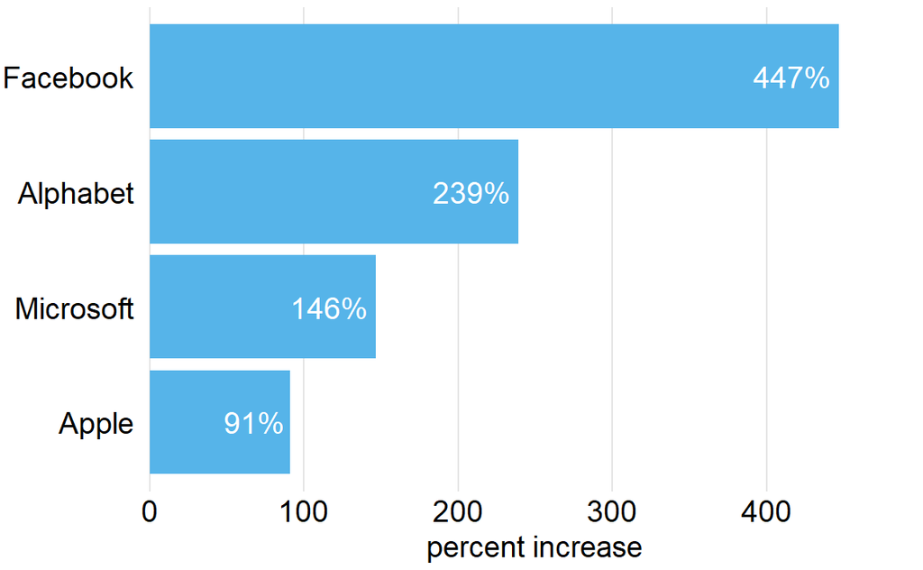

Figure 52: Percent increase in stock price from June 2012 to June 2017, for four major tech companies. Because the bars run horizontally, vertical grid lines are appropriate here. Data source: Yahoo Finance

```r
perc_increase <- filter(ungroup(tech_stocks), date == ymd("2017-06-01")) %>%
  mutate(perc=100*(price-index_price)/index_price,
         label=paste(as.character(round(perc)), "%", sep="")) %>%
  arrange(perc)
perc_increase$ticker <- factor(perc_increase$ticker, levels=perc_increase$ticker)
perc_plot <- ggplot(perc_increase, aes(x=ticker, y=perc)) +
  geom_col(fill="#56B4E9") +
  geom_text(aes(label=label), color="white", hjust=1.1, size=5,
            family = dviz_font_family) +
  scale_y_continuous(#name="percent increase\n(June 2012 to June 2017)",
                     name="percent increase",
                     limits=c(0, 499),
                     expand=c(0, 0)) +
  scale_x_discrete(name = NULL,
                     breaks = c("FB", "GOOG", "MSFT", "AAPL"),
                     labels = c("Facebook ", "Alphabet ", "Microsoft ", "Apple ")) +
  coord_flip(clip = "off") +
  theme_dviz_vgrid(rel_small = 1) +
  theme(axis.line.y = element_blank(),
        axis.ticks = element_blank(),
        axis.ticks.length = grid::unit(0, "pt"))
perc_plot
```

### 0.2.9 Use larger axis labels

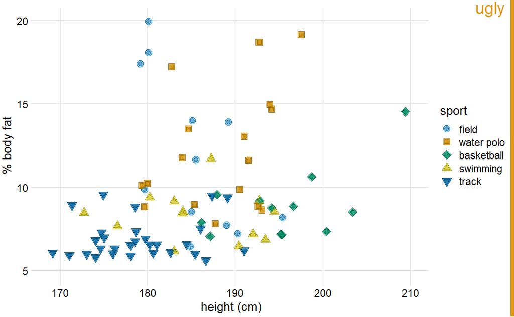

```r
stamp_ugly(p + geom_point(size = 1.5) +
             theme_dviz_grid(10) + theme(plot.margin = margin(7, 7, 3, 1.5)))
```

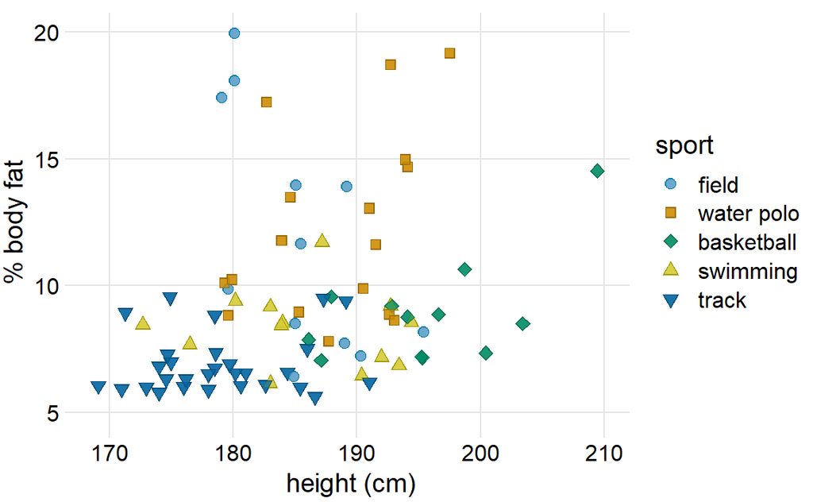

Figure 54: Percent body fat versus height in male athletes. All figure elements are appropriately scaled. Data source: @Telford-Cunningham-1991

```r
p + geom_point(size = 2.25) +
  theme_dviz_grid() + theme(plot.margin = margin(7, 7, 3, 1.5))
```

Importantly, we can overdo it and make the labels too big (Figure 55). Sometimes we need big labels, for example if the figure is meant to be reduced in size, but the various elements of the figure (in particular, label text and plot symbols) need to fit together. In Figure 55, the points used to visualize the data are too small relative to the text. Once we fix this issue, the figure becomes acceptable again (Figure 56).

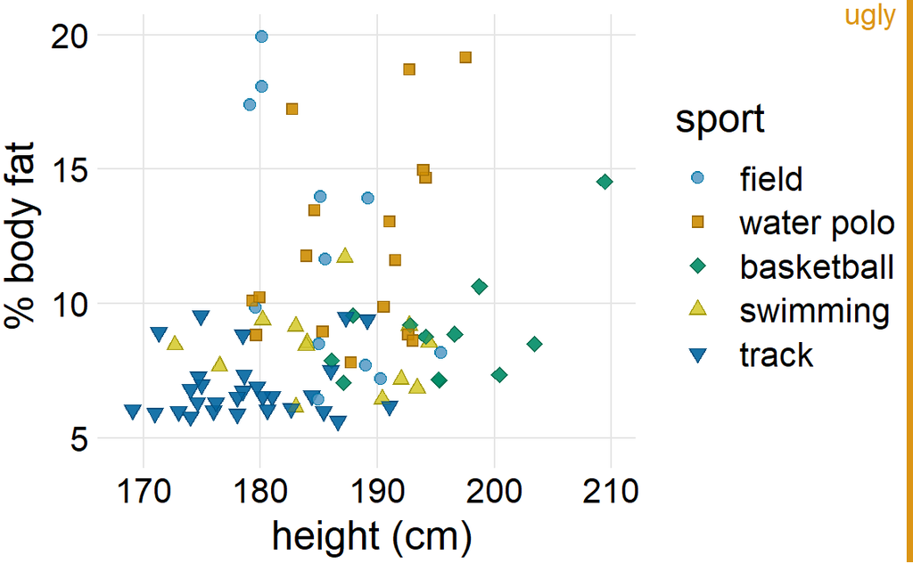

Figure 55: Percent body fat versus height in male athletes. The text elements are fairly large, and their size may be appropriate if the figure is meant to be reproduced at a very small scale. However, the figure overall is not balanced; the points are too small relative to the text elements. Data source: @Telford-Cunningham-1991

```r
stamp_ugly(p + geom_point(size = 2.25) +
             theme_dviz_grid(19) + theme(plot.margin = margin(7, 7, 3, 1.5)))
```

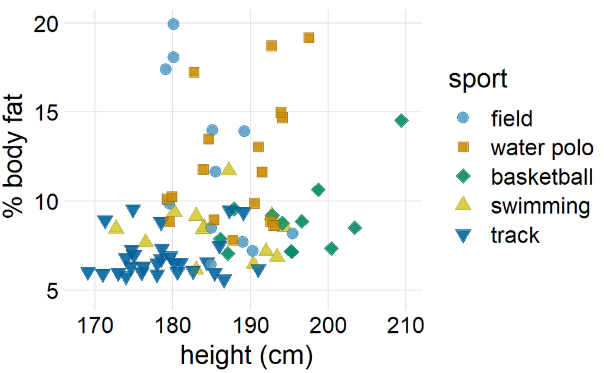

Figure 56: Percent body fat versus height in male athletes. All figure elements are sized such that the figure is balanced and can be reproduced at a small scale. Data source: @Telford-Cunningham-1991

```r
p + geom_point(size = 3.5) +
  theme_dviz_grid(19) + theme(plot.margin = margin(7, 7, 3, 1.5))
```

You may look at Figure 56 and find everything too big. However, keep in mind that it is meant to be scaled down. Scale the figure down so that it is only an inch or two in width, and it looks just fine. In fact, at that scaling this is the only figure in this chapter that looks good.

Always look at scaled-down versions of your figures to make sure the axis labels are appropriately sized.